# A Representative Sample of Australian Participant’s Attitudes Towards the COVIDSafe App.

Paul Garrett$^1$, Joshua White$^1$, A/Prof Daniel Little$^1$, A/Prof Amy Perfors$^1$, Prof Yoshihisa Kashima$^1$, Prof Stephan Lewandowsky$^2$, & Prof Simon Dennis$^1$

$^1$Complex Human Data Hub, School of Psychological Sciences, The University of Melbourne.

$^2$School of Psychological Sciences, The University of Bristol.

Data collected: 23/6/2020 - 25/6/2020. Initial upload: 01/7/2020.

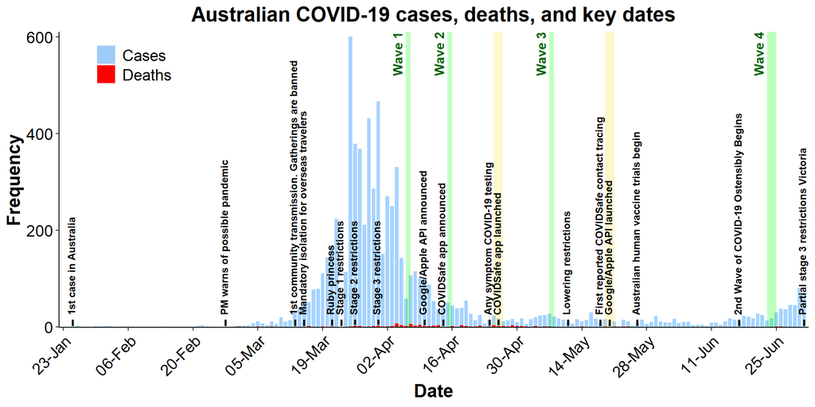

# Results

## Status of the initial data collected

The results presented in this preliminary report represent a snapshot from 596 participants collected on the 23rd June 2020 during the fourth wave of data collection for the project ‘Establishing the social licence for Government tracking in Australia’.

The reported representative sample was gathered through the data collection platform Dynata. 596 participants reported their demographics and their perceived severity of the COVID-19 outbreak in Australia and around the world. They then viewed a description of the COVIDSafe app, before answering questions about their attitudes towards the app, their views on their government during the COVID-19 pandemic, and their world views.

### Notes on cleaning the data.

1. Of the initial 596 participants collected, 36 participants were removed prior to analysis for indicating a country of residence other than Australia.
2. A further 1 participant was removed prior to analysis for indicating they were below the age of 18.
3. An additional 85 participants did not pass the attention check.
4. Finally, 45 participants began and did not complete the survey.

After cleaning the data for the above participants, the final sample at analysis was 429 participants.

## Descriptive Statistics

Gender was evenly divided between men (50%) and women (49%), and 94% of participants reported that they currently use a smartphone. Within our sample, participants most frequently reported as having a university education (57%) or a higher school education (34%). Ages ranged from 19 years to 91 years (M = 47 years, SD = 17 years). The distribution of reported ages was roughly uniform within the age range 20–80, and under represented for ages 80+.

| Gender identification: Percentages | Gender identification: Percentages Percent |
| --- | --- |
| Gender |  |
| Men | 50.1 |
| Women | 49.4 |
| Other | 0.2 |
| Prefer not to say | 0.2 |
| #Total cases | 429 |

| Level of education: Percentages | Level of education: Percentages Percent |
| --- | --- |
| Education |  |
| Did Not Graduate High School | 8.2 |
| Graduated High School | 34.5 |
| Graduated University | 57.3 |
| #Total cases | 429 |

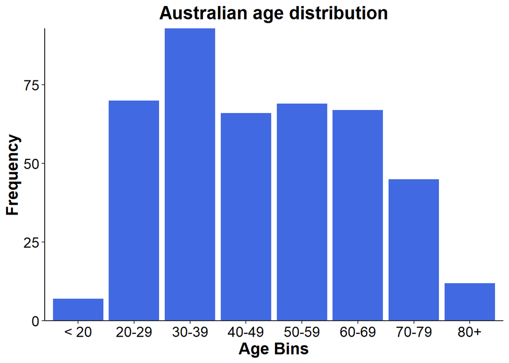

| State representation: Percentages | State representation: Percentages Percent |
| --- | --- |
| State |  |
| NSW | 30.8 |
| VIC | 24.0 |
| QLD | 20.7 |
| SA | 7.9 |
| WA | 11.0 |
| NT | 1.2 |
| TAS | 2.3 |
| ACT | 2.1 |
| Other |  |
| #Total cases | 429 |

## Impacts of COVID

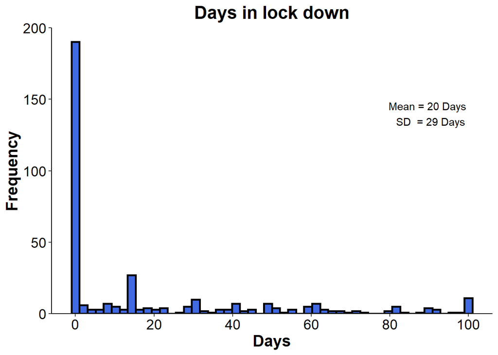

| I have lost my job: Percentages | I have lost my job: Percentages Percent |
| --- | --- |
| I lost my job |  |
| No | 83.9 |
| Yes | 16.1 |
| #Total cases | 429 |

| Information source: Percentages | Information source: Percentages Percent |
| --- | --- |
| Information source |  |
| Newspaper (printed or online) | 17.9 |
| Social media | 11.2 |
| Friends/family | 3.7 |
| Radio | 5.8 |
| Television | 52.0 |
| Other | 6.1 |
| Do not follow | 3.3 |
| #Total cases | 429 |

| Somebody I know tested positive for COVID-19: Percentages | Somebody I know tested positive for COVID-19: Percentages Percent |
| --- | --- |
| Tested pos someone I know |  |
| No | 94.6 |
| Yes | 5.4 |
| #Total cases | 429 |

## Compliance with COVID Restrictions

When asked what percentage of the population was complying with government policies regarding social distancing, the average estimate was 60% (SD = 24%; see below figure). When asked if they were complying with Governmental lockdown policies, 66% of participants indicated that they were either completely complying or going beyond policy suggestions. 1% indicated they were not complying at all, while 34% indicated some degree of partial compliance.

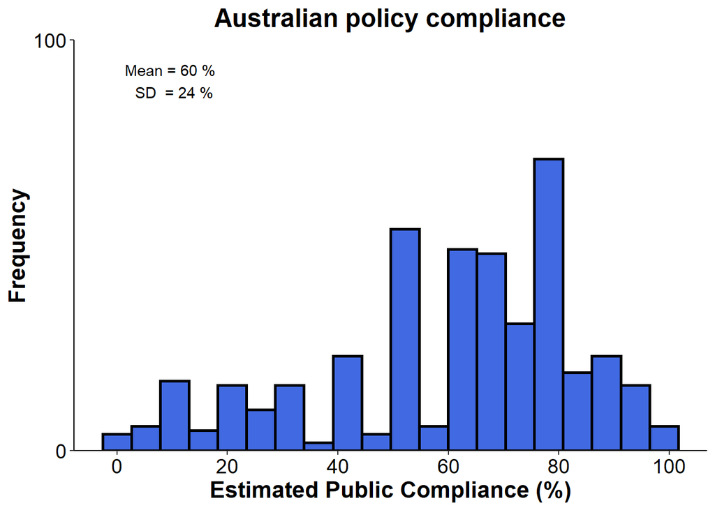

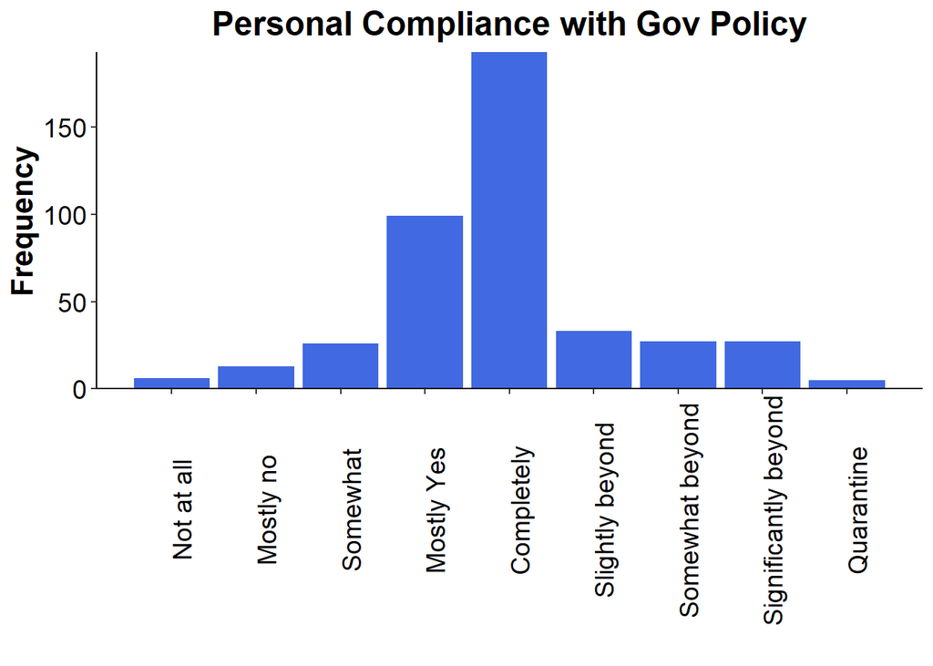

## Perceived Risk of COVID

We asked participants about the perceived risk COVID-19 poses for themselves and those around them. Responses were made on a likert scale with values:

1. Not at all,
2. Slightly,
3. Somewhat,
4. Very,
5. Extremely.

When asked about COVID-19 within the Australian population, participants most frequently reported the virus to be moderate in severity and that the virus posed a ‘somewhat’ or ‘very’ harmful risk to their personal health. 96% of participants reported the virus to be at least ‘a little severe’ (2) for the population and at least ‘a little harmful’ (2) to their health.

When asked about their concern over testing positive to COVID-19, responses were skewed and participants reported as being less concerned than during previous assessments. When asked about their concern over someone they know testing positive to COVID-19, participants responses were negatively skewed. This indicates a bias towards concern over others in their community, such as the elderly or nurses and doctors, testing positive to COVID-19. This trend has remained stable across our three waves of data collection. A strong correlation was observed between concern for others and concern for self (r = .8), and between risk of personal harm and concern for self (r = .64).

Finally, we asked participants to report their estimates on the number of fatalities across a range of countries with moderate-to-high media coverage in Australia. Responses were made on a sliding scale ranging from 0 - 50,000; results are reported in estimated deaths per 1000 (see violin plot).

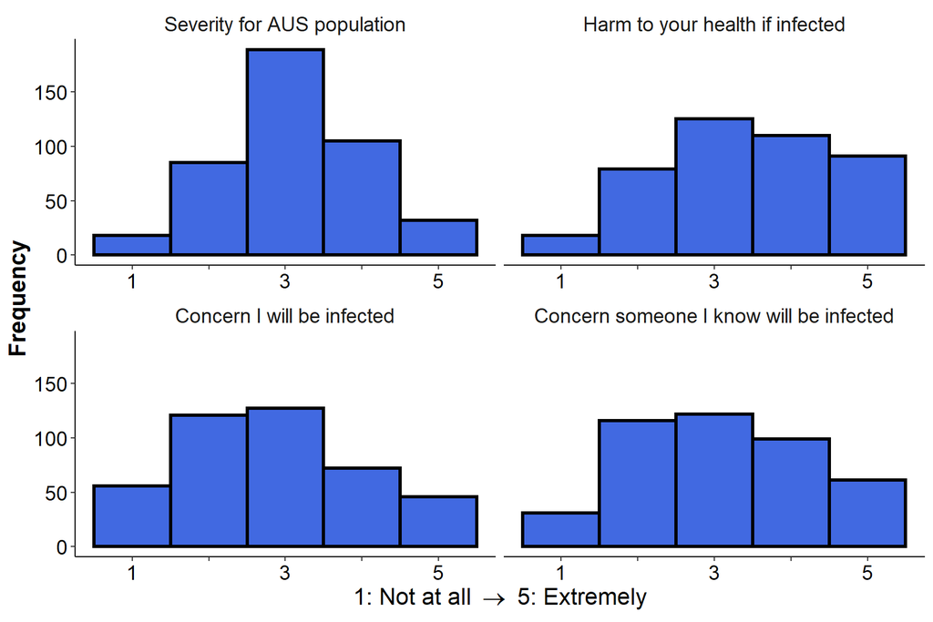

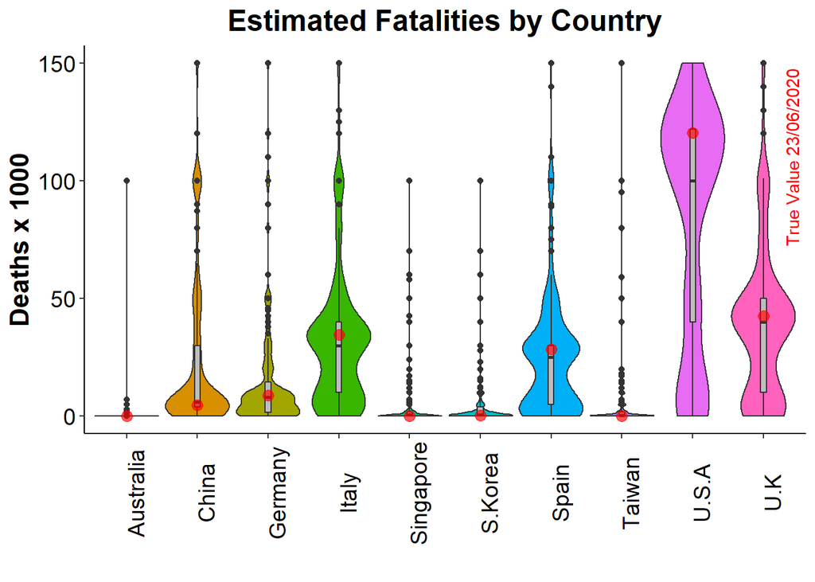

# The COVIDSafe App

## COVIDSafe - App Perception

The Australian Government has recently released the COVIDSafe smartphone app to trace the spread of COVID-19. We asked participants to assess their understanding of the COVIDSafe app, before presenting them a factual description of the app.

We asked participants who had access to the data collected by COVIDSafe. Participants could choose from one-or-more of the following options: - Me - Contact tracers working for the Australian Government’s Health Department - Other Government Employees who are not contract tracers - The public - Scientists / Researchers - I don’t know

When asked who had access to the data collected by COVIDSafe, 51% correctly reported only “contact tracers working for the health department”. Of the remaining responses, 17% indicated they did not know and 6% indicated the public had access to the data. All remaining responses were a combination of options, each representing less than 3% of the sample exept for the combinations of ‘scientitsts’ and ‘government employees who are not contact tracers’ 6%, and “contact tracers” and “me” 3%.

When asked what technology does the COVIDSafe smartphone app use, **45% of participants responded Bluetooth**, 30% responded Location data, 4% responded Mobile phone tower, and 21% responded that they did not know. In a later section of the survey, we ask if participants have downloaded the COVIDSafe app - we will now report the same results broken down by those who have and have not downloaded the app.

Of the 429 participants, **45% did download the COVIDSafe app**. Of these participants, 58% reported that the app uses Bluetooth, 25% location data, 7% mobile network data, and 10% reported that they did not know.

Of the 429 participants, **55% did not download the COVIDSafe app**. Of these participants, 34% reported that the app uses Bluetooth, 34% location data, 3% mobile network data, and 30% reported they did not know.

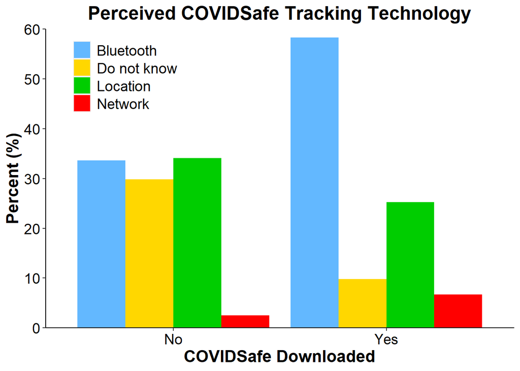

## COVIDSafe - App Description

Participants were provided the following description of the COVIDSafe app before they proceeded to answer the remaining survey questions.

“The COVID-19 pandemic has rapidly become a worldwide threat. Containing the virus’ spread is essential to minimise the impact on the healthcare system, the economy, and save many lives. The Australian Government has recently released the COVIDSafe smartphone app to help identify and contact those who may have been exposed to people with COVID-19. **The use of this app is completely voluntary, but the government has explicitly stated that easing social distancing restrictions depends at least in part on the degree of community uptake of this voluntary app.** This is because, the more people that download and use this app the more effectively it will help to contain the spread of COVID-19. **The app works with bluetooth and no location data is collected**: when two people are near each other, their phones connect and keep a record of all these connections. If a person is later identified as being infected, that person may **voluntarily upload their bluetooth contacts to a secure server accessible only to the Health Department of the Australian Government. This data would only be used by the Health Department of the Australian Government to contact those who might have been exposed to COVID-19.**”

## COVIDSafe - The Current Effective Use

45% of participants downloaded the COVIDSafe app, however, downloads do not always translate to effective usage. We examine whether these participants:

1. Are registered on the app?
   - Yes 85%
   - No 5%
   - Don’t know 10%
2. Keep the app installed on their phone?
   - Yes 92%
   - No 8%
3. Keep Bluetooth on?
   - Yes 64%
   - Only when I leave the house 22%
   - No 8%
   - I don’t know 6%
4. Have the app downloaded, are registered and have bluetooth switched on?
   - Yes 62%
   - Only when I leave the house 23%
   - No 9%
   - I don’t know 6%
5. Would upload their data if they tested positive to COVID-19?
   - Yes 97%
   - No 3%
6. Have tried to share the app with others?
   - Yes 55%
   - No 44%
7. When they downloaded the COVIDSafe app?
   - The day it was released 29%
   - In the week after it was released 57%
   - Any other time 14%
8. What kind of internal operating system (iOS) their phone uses:
   - Apple 43%
   - Android 50%
   - Other 0.7%
   - Don’t know 0.7%
   - Don’t own a phone 6%
9. Of those who have downloaded the app on an Apple iOS device, do they leave their phone screen unlocked, Bluetooth on, and COVIDSafe open on the front screen when in public?
   - Yes 45%
   - No 55%

Our findings suggest that up to 85% of COVIDSafe app users are registered & have bluetooth switched on when they leave the house and interact with members of the general public. Under ideal circumstances, this would be equivilant to the rate of effective COVIDSafe usage; however, this is not the case.

The COVIDSafe app on the Apple iOS does not work as intended unless the phone screen is unlocked, Bluetooth is switched on, and the COVIDSafe app is open on the front screen. We asked Apple iOS users if they followed these procedures to calculate a true effective usage rate for COVIDSafe. **Our results show that the true rate of effective app usage among COVIDSafe users is 61%.**

Although only 1% of our sample have received a COVID-19 diagnosis, 97% indicated they would upload their contact information through COVIDSafe if they were diagnosed with the virus.

55% of COVIDSafe users have tried to share the app with friends and family. The COVIDSafe app has built-in functionality that allows users to share the app with others. Of those who downloaded COVIDSafe, 32% knew of this functionality, 19% have used this to share the app with others, and 61% intend to use this functionality to share the app with others in the future.

## COVIDSafe - Reasons for downloading the app

It is important to understand why individuals choose to download and use the COVIDSafe app. Below, we present the results of a rank ordered question set where participants indicated from most-to-least those factors that convinced them to download COVIDSafe. Options included:

1. To return to normal activities
2. To protect my health
3. To protect the health of others
4. To follow Government recommendations
5. To help the economy

In general, we observe that participants were most motivated to download the app so as to follow Governmnet policy and return to normal activities, then to protect their health and the health of others. Participants were least motivated by the prospect of helping the economy, with 50% of the sample choose this as their last rank-ordered option.

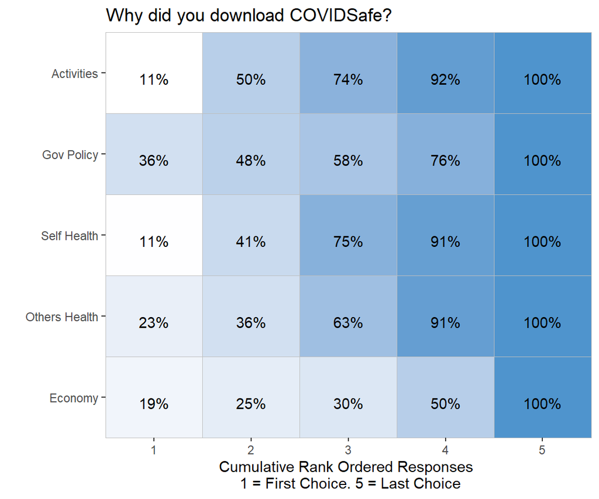

### COVIDSafe - Downloading due to others

Individuals within the public domain may convince others to download the COVIDSafe app. Here, we asked participants to rank order those individuals who most convinced them to download the COVIDSafe app. Responses included:

1. The Prime Minister
2. Other politicians
3. Government advertising
4. Friend or family
5. Other public figure
6. Scientist or Researcher
7. Nobody, I did not need convincing

First-order responses primarily showed that the Prime Minister and Government advertising were key motivators for downloading COVIDSafe, however, second order responses showed that scientists and other public figures played a major role in convincing the public. The following cumulative response table shows responses to each item sorted by second-order responses.

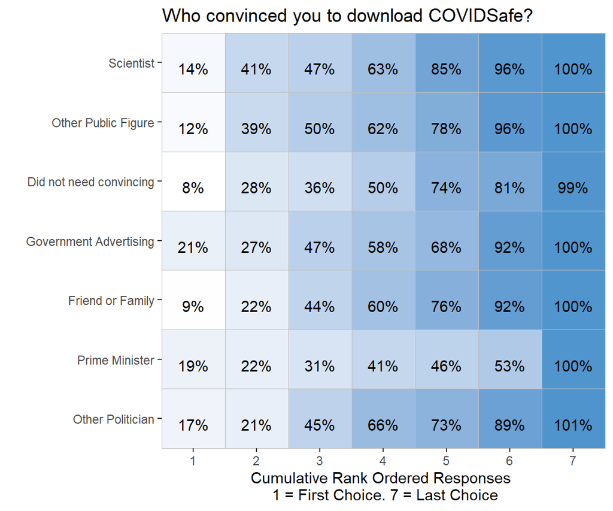

# COVIDSafe - Non Users & Future Users

In this next section, we examine responses from the 55% of individuals who have not yet downloaded the COVIDSafe app. This analysis will cover two sub-groups: those who intend to download the app in the future, and those who never intend to download the COVIDSafe app.

## COVIDSafe - Non Users who intend to download the app

Our findings show that 21% (n = 50) of non-app users (12% total participants) intend to download the app in the future. When asked if they planned to upload their data through the app if they tested positive to COVID-19, 50 of the 50 participants indicated that they would.

There are many reasons why individuals may yet download the app. We asked participants to rank order seven potential reasons for not having yet download the app from most applicable to least applicable. Responses included:

1. I have not had time
2. I have not left the house yet
3. Technical issues
4. I am waiting to see if enough people download the app for it to be effective
5. I have been considering the pros and cons of downloading the app
6. It has not crossed my mind
7. I do not know how to download the app

The following figure provides the rank ordered responses to the above options from most applicable (1) to least applicable (7) sorted by the second-order responses.

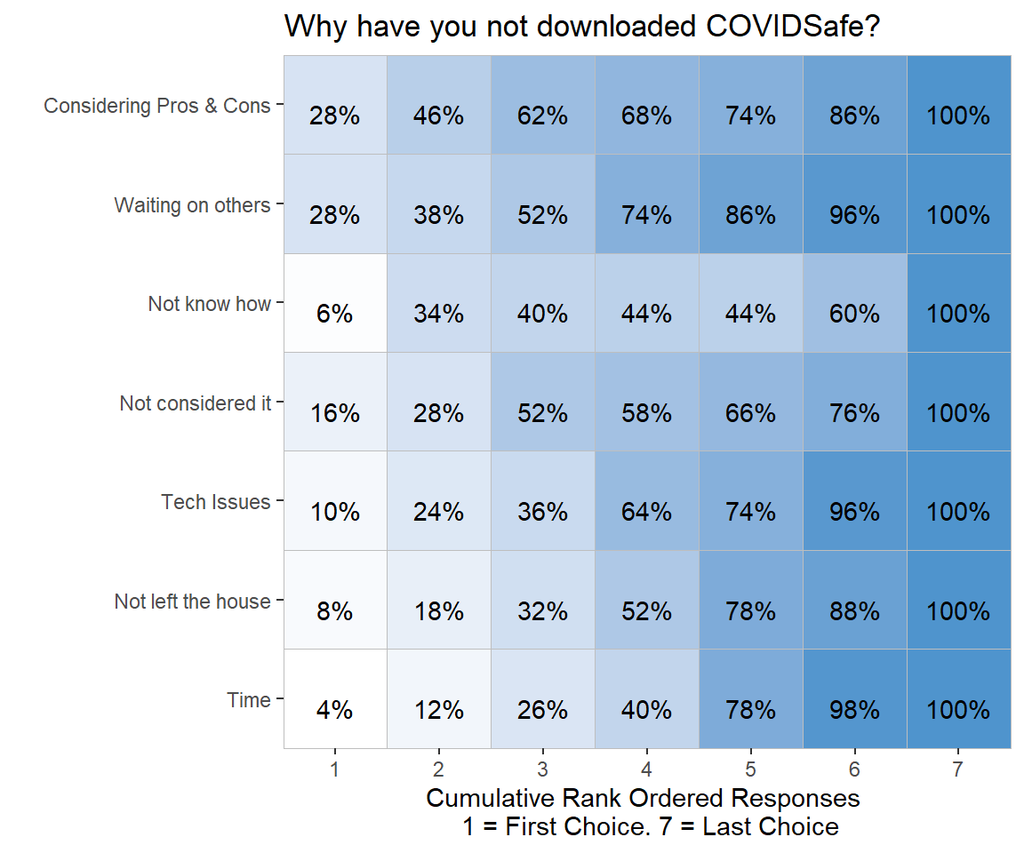

## COVIDSafe - Non Users who do not intend to download the app

There are many reasons why individuals may not wish to download the app. We asked participants to rank order ten possible responses:

1. I am concerned about privacy
2. I don’t trust the Government with my data
3. I am worried about battery usage on my phone
4. I don’t think it’s going to be effective
5. I am worried about normalising Government tracking
6. I am concerned about the Government encroaching on civil liberties
7. I don’t know how to download it
8. I don’t own a smart phone
9. My phone is too old to run the app
10. I am concerned about others gaining access to my data

The following figure provides the rank ordered responses to the above options from most applicable (1) to least applicable (10). The primary reasons for not downloading COVIDSafe were concerns over privacy, normalising government tracking, government trust, a belief the app would not be effective, and battery usage.

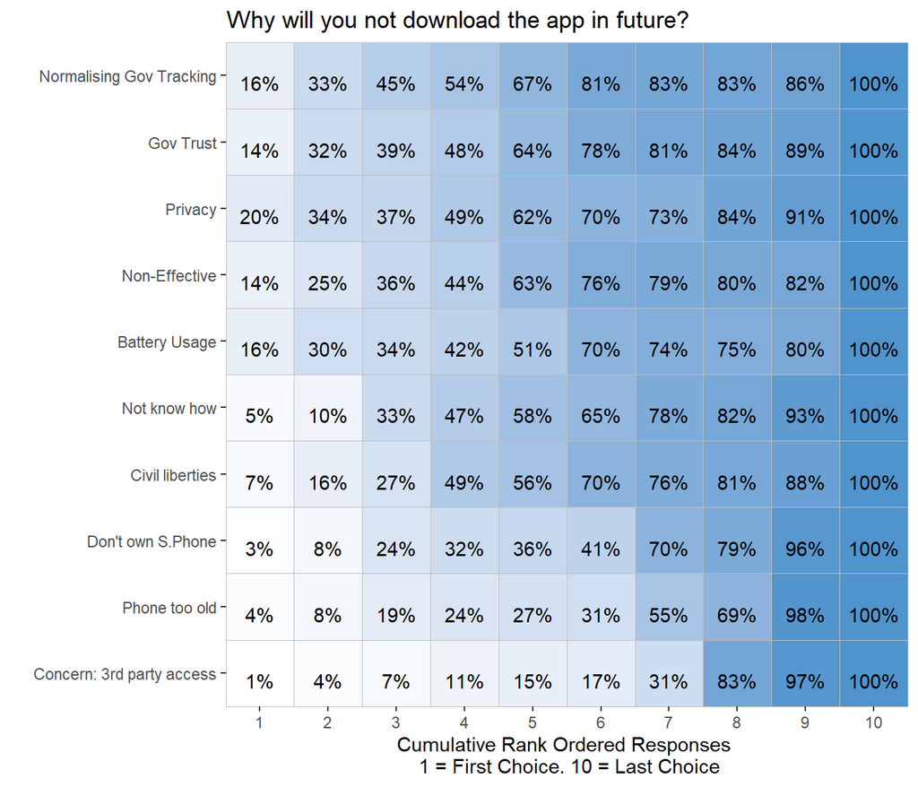

### COVIDSafe - Who influenced you to not download the app?

Similarly, people my be influenced by other individuals into not downloading the COVIDSafe app. We asked participants to rank order the following individuals who may have convinced them **not** to download the app:

1. The Prime Minister
2. Other politicians
3. Government advertising
4. Friend or family
5. Other public figure
6. Scientist or Researcher
7. Nobody, I did not need convincing

[figure not shown]

### COVIDSafe - Perceived Effectiveness, now and in the future

In our previous work, participant responses were quite different to hypothetical tracking scenarios when mobile phone tracking was voluntary vs mandatory. The COVIDSafe app is currently a voluntary app, however, it has been suggested that the Government make this app mandatory. We asked participants, if an insufficient number of Australians download the COVIDSafe smartphone app, should the government make downloading the app mandatory by issuing fines to those who do not comply? 72% of participants responded no.

We next asked all participants a set of general questions targeting the effectiveness of the COVIDSafe app. We asked participants to estimate the current percentage of Australians’ who are using the COVIDSafe app. When then asked participants to estimate the percentage of Australians’ who will be using the COVIDSafe app in the future. Results are displayed in the Figure below.

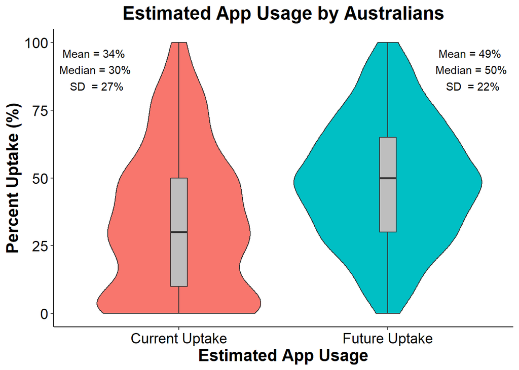

In our previous work, participant responses were quite different to hypothetical scenarios when mobile phone tracking was voluntary vs mandatory. The COVIDSafe app is currently a voluntary download, however, it has been suggested the Government may consider making this app mandatory. We asked participants, if an insufficient number of Australians download the COVIDSafe smartphone app, should the government make downloading the app mandatory by issuing fines to those who do not comply? 72% of participants responded no.

Finally, we asked a series of questions about participant’s perception of the COVIDSafe app, now that they had read the app description and responded to several questions. These general items can be broken into two groups: assessing the efficacy of the app to impact the spread of COVID-19 & assessing the public’s understanding of the COVIDSafe app and their personal concerns about the app. Our questions regarding the app’s ability to impact the spread of COVID-19 include:

1. How confident are you that the app will reduce your likelihood of contracting COVID-19?
2. How confident are you that the app will help you resume your normal activities more rapidly?
3. How confident are you that the app will reduce the spread of COVID-19 in the community?
4. How confident are you that other people like yourself will be able to download and use the app effectively.

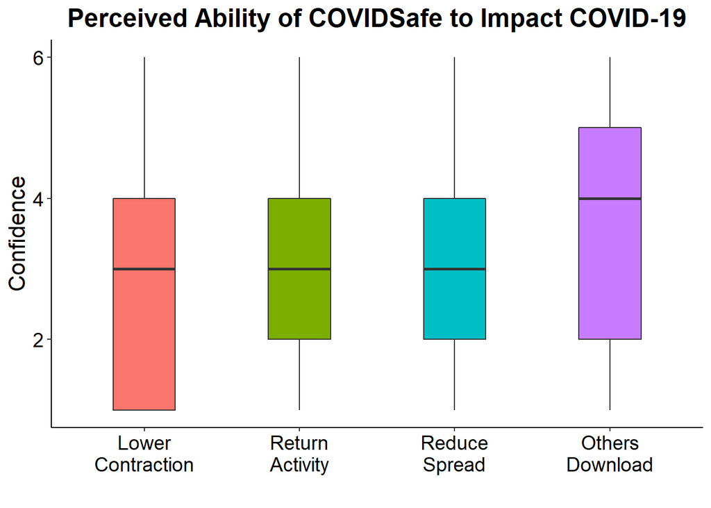

## COVIDSafe - Understanding of the app & personal concerns

Our questions regarding the public’s understanding of the COVIDSafe app and their personal concerns about the app included:

1. How easy is it for people to decline participation in COVIDSafe contact tracing?
2. To what extent is the Government only collecting the data necessary to achieve the purposes of the COVIDSafe app?
3. How sensitive is the data being collected by the COVIDSafe smartphone app?
4. How serious is the risk of harm that could arise from the COVIDSafe smartphone app?
5. How much do you trust the Government to use the COVIDSafe smartphone app data only to deal with the COVID-19 pandemic?
6. How much do you trust the Government to be able to ensure the privacy of each individual that uses the COVIDSafe smartphone app?
7. How secure is the data that is collected by the COVIDSafe smartphone app?
8. To what extent do people have ongoing control of their data from the COVIDSafe smartphone app?

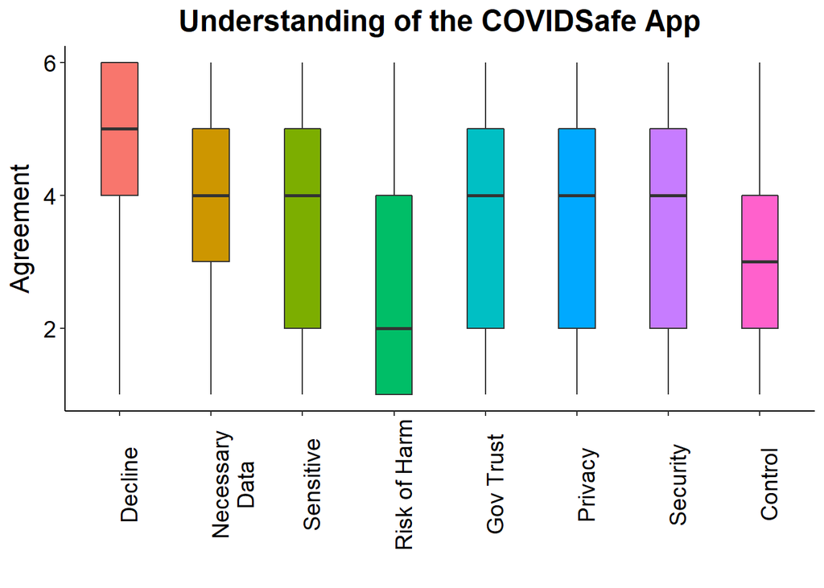

## World Views: Government, Travel, & Technology

When asked if they approved of the Government’s handling of the COVID-19 pandemic, 75% somewhat-to-strongly approved, and 11% somewhat-to-strongly disapproved.

We asked participants about their perceptions of how technology has impacted their lives and the lives of other Australians. The questions were:

1. Science and technology are making our lives healthier, easier, and more comfortable
2. Because of science and technology, there will be more opportunities for the next generation.
3. All things considered, would you say that the world is better off, or worse off, because of science and technology?

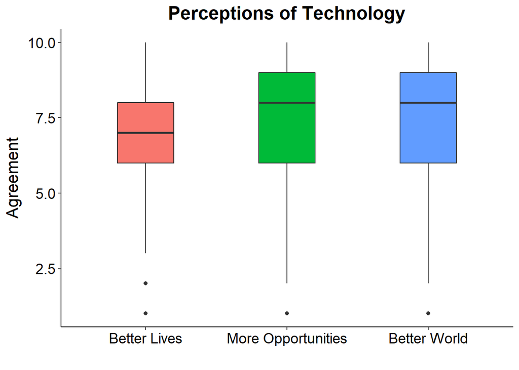

As travel restrictions lower, COVID-19 tracking apps may become a mandatory part of entering a country. We asked participants the following:

1. I would willingly download and use another country’s COVID-19 tracking app if it were a condition to travel to that country.
- Somewhat-to-strongly agree 54%
- Neither agree nor disagree 16%
- Somewhat-to-strongly disagree 29%
2. I think all arrivals to Australia should be required to download and use COVIDSafe as a condition of their entry.
- Somewhat-to-strongly agree 67%
- Neither agree nor disagree 17%
- Somewhat-to-strongly disagree 14%

Finally, we assessed whether there was a correlation between the composite measures of three worldview items, to i) the perceived risk of COVID-19, and ii) the composite of two Government trust items. Results indicate no significant correlations between Worldview (interval depicts increasing libertarlianism) and the perceived risk of COVID-19 or the degree of Governmnet trust in Australia.

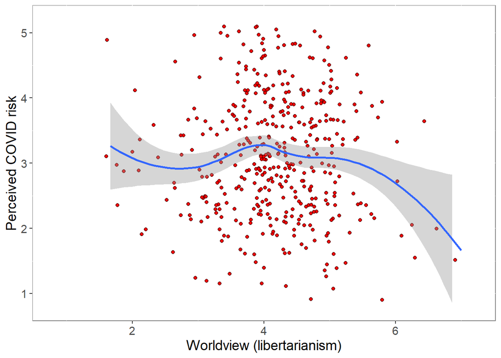

```
##
##  Pearson's product-moment correlation
##
## data:  Data$WorldView and Data$COVIDrisk
## t = -0.46163, df = 420, p-value = 0.6446
## alternative hypothesis: true correlation is not equal to 0
## 95 percent confidence interval:
##  -0.11772534  0.07309664
## sample estimates:
##         cor
## -0.02251945
```

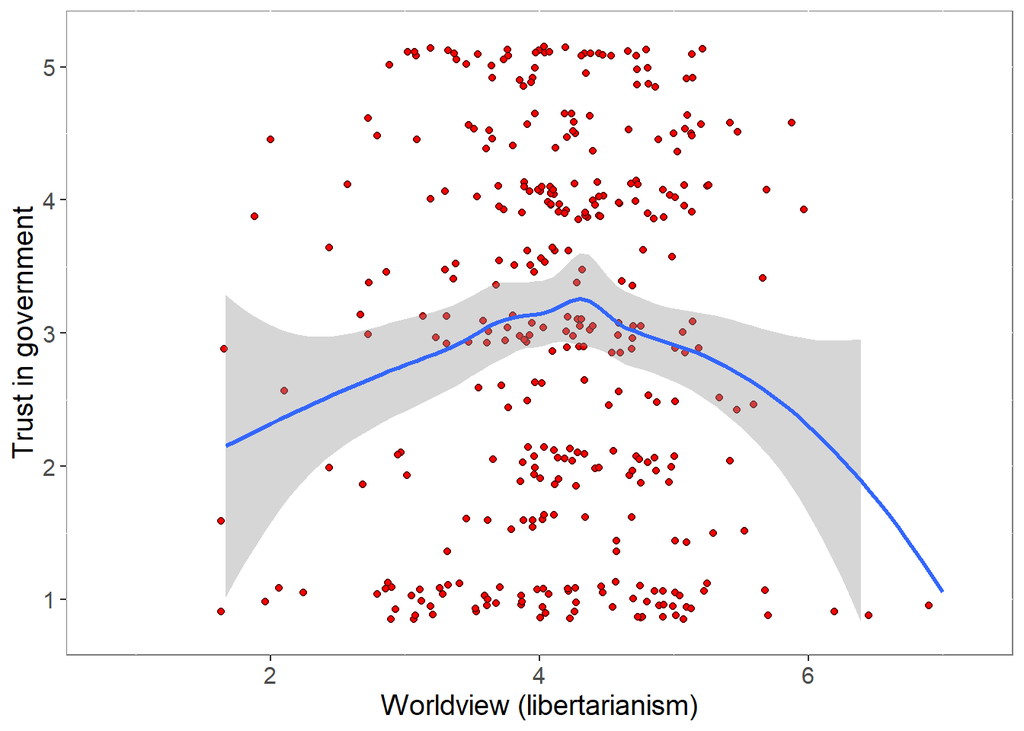

```
##
##  Pearson's product-moment correlation
##
## data:  Data$WorldView and Data$govtrust
## t = 0.6229, df = 420, p-value = 0.5337
## alternative hypothesis: true correlation is not equal to 0
## 95 percent confidence interval:
##  -0.0652679  0.1254754
## sample estimates:
##        cor
## 0.03038034
```